# ANOVA and Intro to Linear Regression

## Lab Report Template

Before you get started, download the R Markdown template for this lab. Remember all of your code and answers go in this document:

```r
download.file("https://jacobfhsmith.github.io/STA101L-Spring2021/sta101_lab8.Rmd", destfile="sta101_lab8.Rmd")
```

## Packages

```r
library(readxl)
library(tidyverse)
```

## Data

Dataset from the 2016 [American National Election Study](https://electionstudies.org/data-center/2016-time-series-study/)

```r
anes = read_excel("ANESANOVA.xlsx") ## This should be your path to the data
str(anes)
```

```
## tibble [4,270 × 9] (S3: tbl_df/tbl/data.frame)
##  $ CaseID            : num [1:4270] 1 2 3 4 5 6 7 8 9 10 ...
##  $ DemTherm          : num [1:4270] 0 15 50 30 70 15 85 0 15 50 ...
##  $ GOPTherm          : num [1:4270] 70 85 50 70 40 30 15 40 60 50 ...
##  $ HillaryTherm      : num [1:4270] 0 0 50 0 15 0 85 15 15 60 ...
##  $ TrumpTherm        : num [1:4270] 85 85 60 60 0 50 0 85 60 50 ...
##  $ LikelyVoter       : chr [1:4270] NA NA NA NA ...
##  $ LikelyVoterNumeric: num [1:4270] NA NA NA NA NA 1 NA 1 5 NA ...
##  $ Party             : chr [1:4270] NA NA "3. Closer to Democratic" "1. Closer to Republican" ...
##  $ Science           : num [1:4270] 70 70 70 50 85 50 100 60 70 85 ...
```

## ANOVA

Analysis of variance (ANOVA) has the following hypothesis test framework:

$H_0:$ Numeric variable X has the same mean across all subgroups

$H_A:$ At least one of the subgroups has a different mean than the others

```r
aov1 = aov(HillaryTherm~Party, anes)
summary(aov1)
```

```
##               Df Sum Sq Mean Sq F value Pr(>F)
## Party          2 376127  188064   294.3 <2e-16 ***
## Residuals   1557 994788     639
## ---
## Signif. codes:  0 '***' 0.001 '**' 0.01 '*' 0.05 '.' 0.1 ' ' 1
## 2710 observations deleted due to missingness
```

Now, let’s run a regression:

```r
lm1 = lm(HillaryTherm~Party, anes)
summary(lm1)
```

```
##
## Call:
## lm(formula = HillaryTherm ~ Party, data = anes)
##
## Residuals:
##     Min      1Q  Median      3Q     Max
## -56.713 -17.754  -2.754  15.113  82.246
##
## Coefficients:
##                              Estimate Std. Error t value Pr(>|t|)
## (Intercept)                    17.754      1.132   15.69   <2e-16 ***
## Party2. Neither                17.133      1.548   11.07   <2e-16 ***
## Party3. Closer to Democratic   38.960      1.609   24.21   <2e-16 ***
## ---
## Signif. codes:  0 '***' 0.001 '**' 0.01 '*' 0.05 '.' 0.1 ' ' 1
##
## Residual standard error: 25.28 on 1557 degrees of freedom
##   (2710 observations deleted due to missingness)
## Multiple R-squared:  0.2744, Adjusted R-squared:  0.2734
## F-statistic: 294.3 on 2 and 1557 DF,  p-value: < 2.2e-16
```

Note: ANOVA is essentially a special case of linear models.

## Exercise 1 15%

Is there a significant difference in the rating of the Democratic Party among voters with different political parties? Use aov() to find out.

## Simple Linear Regression

$$Y_i = \beta_0 + \beta_1 X_i + \epsilon_i, \text{ where } \epsilon_i \overset{iid}{\sim} N(0, \sigma^2) \text{ for all } i$$

Conditions:

- Linearity: The relationship between X and the mean of Y is linear and residuals have zero mean.
- Homoscedasticity: The variance of residuals is the same for any value of X.
- Independence: Observations are independent of each other.
- Normality: For any fixed value of X, Y is normally distributed.

### Visualization

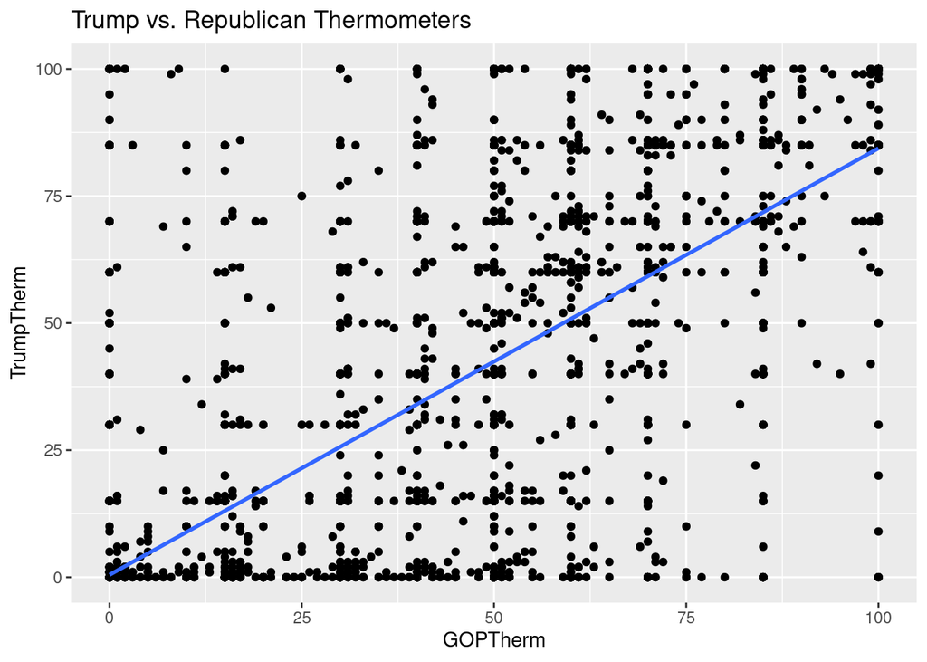

```r
lm_ex = lm(data = anes, TrumpTherm~GOPTherm)
ggplot(anes, aes(x = GOPTherm, y = TrumpTherm)) + geom_point() + geom_smooth(method='lm', se=FALSE) + ggtitle("Trump vs. Republican Thermometers")
```

## Exercise 2 10%

Plot a scatterplot for Rating of Hillary Clinton (`HillaryTherm`) and Rating of the Democratic Party (`DemTherm`). Add a line of best fit to it.

## Exercise 3 10%

Add position=position_jitter() in geom_point() and comment on the change. What does this new argument do?

## lm()

lm() function has two required arguments: the data and the formula for the model. Y~X1 + X2 is the formula, with Y being the response and X1 and X2 being the predictors.

For example, let’s fit a simple linear regression model for `TrumpTherm` (response) and `GOPTherm` (predictor):

```r
lm_ex = lm(TrumpTherm~GOPTherm, data = anes)
summary(lm_ex)
```

```
##
## Call:
## lm(formula = TrumpTherm ~ GOPTherm, data = anes)
##
## Residuals:
##     Min      1Q  Median      3Q     Max
## -84.401 -14.401  -0.478  15.599  99.522
##
## Coefficients:
##             Estimate Std. Error t value Pr(>|t|)
## (Intercept)  0.47843    0.76574   0.625    0.532
## GOPTherm     0.83922    0.01491  56.297   <2e-16 ***
## ---
## Signif. codes:  0 '***' 0.001 '**' 0.01 '*' 0.05 '.' 0.1 ' ' 1
##
## Residual standard error: 26.27 on 4155 degrees of freedom
##   (113 observations deleted due to missingness)
## Multiple R-squared:  0.4327, Adjusted R-squared:  0.4326
## F-statistic:  3169 on 1 and 4155 DF,  p-value: < 2.2e-16
```

The fitted linear model is: (note that the intercept is not significant)
$$TrumpTherm_i = 0.47843 + 0.83922 \cdot GOPTherm_i + \epsilon_i, \text{ where } \epsilon_i \overset{iid}{\sim} N(0, \sigma^2) \text{ for all } i$$
## Exercise 4 15%

Use lm() to fit a simple linear regression model for the two continuous variables in exercise 2, use `HillaryTherm` as the response variable and `DemTherm` as the predictor variable. Print out and look at the model summary. (use summary() function to print out the summary)

## Exercise 5 25%

What are the coefficients? Write out the linear model and interpret them. Are they statistically significant? Hint: You may refer to the example above.

## Exercise 6 20%

Use the plot() function to look at residual plot and normal q-q plot. Are those conditions of the linear model met? If not, should we trust the p-values in the summary?

## Exercise 7 5%

Add another variable to your linear model and print out the summary.

Modified from lab created by Di Deng for Summer 2020.